# 딥러닝 통계적 차익거래의 한국시장 재현

Guijarro-Ordonez, Pelger, and Zanotti (2025), *Deep Learning Statistical Arbitrage*, Management Science

최재필

2026. 08. 24.

## 오늘 말씀드릴 내용

1. **논문 소개**
2. **한국 데이터 재현 결과 (일부)**
3. **질문들**

## 이 논문을 선정한 배경

**1. 개인적 관심**

- 자산운용사에서 국내주식을 운용하는 팀에 있고, 그중 **enhanced index 펀드 전략**을 리서치하고 있습니다.
- 벤치마크 대비 over/underweight로 초과수익을 내는 구조여서 active 부분은 정의상 합이 0인 롱숏인데, 여기에 **의도하지 않은 팩터 노출**이 남습니다.
- 이 논문의 잔차 포트폴리오가 바로 그 노출을 제거한 롱숏 알파입니다.

**2. 석사 논문 주제 적합성**

- **2019년 3월 첫 초고**를 낸 뒤 **2025년 Management Science 게재**까지, 6년간 review 과정을 충분히 거친 논문입니다.
- 그만큼 방법론과 실증이 검증되어 있어 재현의 기준으로 삼기에 안정적이고, 재현과 확장의 기여를 구분해 쓸 수 있습니다.

**3. 재현 용이성**

- 필요 자료가 일별 가격과 팩터 중심이라 확보 난도가 높은 원자료가 적습니다 (IPCA 기업특성은 예외 — 질문 3).
- 저자들이 **논문 코드를 공개**하여 사양을 추정하지 않고 대조할 수 있습니다.

# 1. 논문 소개

## 논문의 핵심 구조

$$\max_{\theta,\ w^{\epsilon}} \ \mathrm{SR}\!\left(w^{R\top}_{t-1}R_t\right) \quad \text{s.t.} \quad \epsilon_t = \Phi_t R_t, \qquad w^{R}_{t-1} = \frac{w^{\epsilon}(\theta_{t-1})^{\top}\Phi_{t-1}}{\lVert w^{\epsilon}(\theta_{t-1})^{\top}\Phi_{t-1}\rVert_1}$$

| 단계 | 대상 | 이 논문의 선택 |
| --- | --- | --- |
| **잔차 생성** | $\Phi_t = I - \beta_t W_{F,t}^{\top}$ | 팩터모형(FF 1/3/5/8 · PCA · IPCA)이 결정 |
| **신호 추출** | $\theta$ | CNN(국소 필터) + Transformer(전역 결합)로 **학습** |
| **비중 배분** | $w^{\epsilon}$ | FFN으로 **학습**, $\lVert w \rVert_1 = 1$ 제약 |

- 세 단계를 각각의 손실함수로 따로 풀지 않고, **하나의 경제적 목적함수 아래 결합 추정**합니다.
- 잔차를 예측하지 않고, 잔차 위의 **거래정책**을 직접 최적화합니다.
- 따라서 레버리지·turnover·거래비용 제약이 사후 절단이 아니라 **학습 시점에 반영**됩니다.
- $\lVert w \rVert_1 = 1$은 레버리지 제약인 동시에 추정 측면에서 정칙화로 작동합니다.
- 목적함수는 Sharpe ratio 또는 평균-분산 중 선택합니다.

## 선행연구에서의 위치

| 흐름 | 대표 연구 | 이 논문의 차별점 |
| --- | --- | --- |
| 고전적 통계적 차익거래 | Gatev et al. (2006) distance, Vidyamurthy (2004) cointegration | 소수 pair가 아니라 **팩터모형 잔차로 고차원 패널 전체**를 대상 |
| 팩터 기반 stat arb | Avellaneda & Lee (2010), Yeo & Papanicolaou (2017) | 후자를 **OU 벤치마크로 채택**. 신호를 모수적으로 고정하지 않고 학습 |
| ML 자산가격결정 (SDF) | Chen, Pelger, Zhu (2022), Kelly, Pruitt, Su (2019, IPCA) | 이들이 설명하는 risk premium의 **잔차**가 이 논문의 대상 |
| ML 수익률 예측 | **Gu, Kelly, Xiu (2020)**, Freyberger et al. (2020) | 목적함수가 **예측(MSE)이 아니라 거래성과** |
| 과거수익률 기반 예측 | Krauss et al. (2017), Lim & Zohren (2021) | “시계열 구조를 아키텍처로 부여해야 한다”는 지적을 **CNN + Transformer**로 수용 |

- 고전 문헌은 포트폴리오 생성·신호 추출·배분을 **따로** 풀어왔고, 이 논문은 셋을 하나의 목적함수로 통합합니다.
- 예측 목적함수 계열(**Gu et al. 2020** 등)은 $\min \mathbb{E}\lVert r_{t+1} - \hat{f}(x_t)\rVert^2$를 풀고 예측치를 사후에 포트폴리오로 바꿉니다.
- MSE는 모든 관측치에 동일 가중을 두지만, 거래에서 중요한 것은 **비중을 실을 수 있는 구간의 정확도**입니다.
- 목적함수가 포트폴리오 수준이면 개별 잔차의 잡음이 횡단면 집계에서 상쇄되어, 짧은 표본에서 기울기 신호의 분산이 작아집니다.
- 기업특성의 용도가 반대입니다 — 예측 문헌은 **예측변수**로, 이 논문은 **직교화 대상**으로 씁니다.

## 무조건부 관점 vs 조건부 관점

팩터모형이 수익률을 잘 설명한다는 것과, 그 잔차에 차익거래 기회가 있다는 것은 **서로 다른 얘기**입니다 (Section 3.6).

무조건부 관점 동일가중 잔차 포트폴리오의 평균수익은 $K \geq 3$에서 **연 1% 이하**, 변동성도 0에 가깝습니다.

잔차는 횡단면적으로 약하게만 상관되어 대부분 분산소거됩니다. 여기까지만 보면 “팩터가 다 설명했다”.

조건부 관점 동일한 잔차를 **시계열 패턴에 따라 최적 거래**하면 평균수익이 **최대 50배**로 커집니다.

잔차의 정보는 무조건부 평균이 아니라 **시간에 따라 변하는 조건부 구조**에 담겨 있습니다.

> “Unconditional means and alphas of asset pricing residuals are a **poor measure of arbitrage opportunities** … the unconditional perspective … could potentially **overstate the efficiency of markets** and the pricing ability of asset pricing models.”

거래전략에 대한 진술이 아니라 **자산가격모형의 평가 방법론에 대한 진술**이며, 이 논문의 학술적 기여가 여기에 있습니다.

## 금융데이터에서의 딥러닝 (1) — 입력과 출력

**입력** — 종목 하나의 잔차 시계열 한 창

- 종목 $n$의 잔차 $\epsilon = \Phi R$를 최근 $L = 30$ 거래일에 대해 **누적경로**로 만든 벡터 $x \in \mathbb{R}^{30}$
  - $x = \left(\epsilon_{n,t-L},\ \sum_{l=1}^{2}\epsilon_{n,t-L-1+l},\ \cdots,\ \sum_{l=1}^{L}\epsilon_{n,t-L-1+l}\right)$ — 30개의 서로 다른 feature가 아니라 **창 안의 30개 시점**입니다
  - “최근 $L$개 lagged return이 신호의 충분통계량”이라는 가정이라, 창 길이가 곧 입력 차원이 됩니다
- 표본 하나 = (종목 $n$, 시점 $t$) 한 쌍. 학습 배치는 **종목 $\times$ 시점으로 pooling**된 30차원 벡터들
- 가격·거래량·기업특성을 feature로 넣지 않습니다. 기업특성은 예측변수가 아니라 $\Phi_t$를 만드는 **직교화 대상**입니다

**모형** — 세 블록을 지나며 shape이 바뀝니다

- CNN (2-layer, 필터폭 $D_{size}=2$, stride 1, left-pad 1 → 수용영역 3일): $\ \mathbb{R}^{30} \rightarrow \mathbb{R}^{30 \times 8}$
  - 각 시점을 $D = 8$개 국소 패턴에 대한 노출로 다시 표현합니다
- Transformer (1-layer, head $H = 4$): $\ \mathbb{R}^{30 \times 8} \rightarrow \mathbb{R}^{8}$
  - attention을 $\alpha_{i,j} = \alpha^{(i)}(\tilde{x}_{30},\, \tilde{x}_j)$로 **마지막 시점 기준으로만** 계산해 $L \times H$가 아닌 $H$차원으로 축약합니다
- 배분 FFN: $\ \mathbb{R}^{8} \rightarrow \mathbb{R}$ — 종목 $n$의 다음 날 잔차 비중 $w^{\epsilon}_n$ 스칼라

**출력** — 다음 날 잔차 포트폴리오 비중

- 횡단면에서 $\lVert w^{\epsilon} \rVert_1 = 1$로 정규화한 뒤 $\Phi_{t}$로 종목 비중 $w^{R}$로 환산
- 손실은 예측오차가 아니라 $-\mathrm{SR}(w^{R\top}R)$

## 금융데이터에서의 딥러닝 (2) — 왜 여기서 성립하는가

제약은 셋입니다 — 창 길이 $L = 30$의 **짧은 시계열**, 일별 잔차의 **낮은 신호대잡음**, 종목 $\times$ 시점의 **고차원 입력**. 논문은 모형을 키우는 대신 **문제의 구조를 모형에 넣어** 해결합니다.

**1. 횡단면 pooling — 잔차의 성질이 이것을 허용합니다**

- 적절한 팩터모형의 잔차는 횡단면적으로 약하게만 상관되고 시간·횡단면 양쪽에서 국소적으로 정상적입니다
- 따라서 동일한 $\theta$와 $w^{\epsilon}$를 전 횡단면에 적용 → 30차원 함수를 $N \times T$ 관측으로 추정합니다
- 원 수익률은 소수 팩터가 지배하고 기업 간 이질성이 커서 이 pooling이 정당화되지 않습니다

**2. 구조적 귀납편향 — OU·Fourier와의 차이가 여기서 납니다**

- OU: 단일 시상수의 선형 평균회귀 → 4차원 신호. 추세와 반전의 **비대칭**을 담지 못합니다
- Fourier: 30일 창의 고정 전역 기저. 위상 이동에 등변이라 **“패턴이 창의 어느 위치에 있었는가”**를 구분하지 못합니다
- 둘 다 **시간 가중이 상태와 무관하게 고정**입니다. attention 가중치는 입력 자체의 함수라 국면에 따라 참조 구간이 이동합니다
- 실제로 학습된 정책은 상승국면에서 창의 앞부분, 하락국면에서 최근 구간에 집중합니다 (Figure 18(b))

**3. 절제된 사양** — 통계적으로 구분되지 않는 후보 중 모수가 가장 적은 사양: 2-layer CNN, $D=8$, 필터폭 2, $H=4$, $L=30$

**4. 경제적 제약의 정칙화 효과** — $\lVert w \rVert_1 = 1$, rolling 1,000일 학습 · 125일 재추정 (750/1,250일에도 강건)

## 논문의 결론

| 신호 · 배분 (미국, 비용 미반영) | FF5 | PCA5 | IPCA5 |
| --- | --- | --- | --- |
| OU + 임계값 규칙 |  | 0.73 |  |
| Fourier + FFN |  | 1.98 |  |
| **CNN + Transformer** | **3.21** | **3.36** | **4.16** |
| CNN + Transformer, 거래비용 반영 |  |  | 0.94 ~ 1.24 |

- 팩터모형 선택은 부차적입니다 — FF5 3.21에서 IPCA5 4.16까지, 정책 간 차이(0.73 → 4.16)보다 작습니다.
- 마찰을 반영하면 4.16 → 0.94 ~ 1.24로 내려갑니다. **4.16은 상한이고 1 내외가 실질값입니다.**

1.23 IPCA-5 팩터의 평균-분산 효율 조합  
(SDF 포트폴리오) Sharpe

4.16 동일 IPCA-5 잔차의  
CNN+Transformer 차익거래 Sharpe

0.02 차익거래 전략을  
IPCA-5 팩터에 회귀한 $R^2$

동일한 팩터모형에서 나온 두 포트폴리오가 **사실상 무상관**입니다. 위험 프리미엄 투자와 차익거래는 개념적으로 구분되며, 투자자는 **둘을 결합해 분산이익**을 얻을 수 있습니다 (Section 3.14).

# 2. 한국 데이터 재현 결과 (일부)

## 재현 조건

| 항목 | 원 논문 (미국) | 본 연구 (한국) |  |
| --- | --- | --- | --- |
| 원자료 | 1978–2016 CRSP | 2015–2026 국내 일별 (8,651,872행, 4,962종목) | 상이 |
| 잔차 표본 | 1998–2016 (19년) | 2020-01-02 ~ 2026-07-20 (1,606일) | **질문 1** |
| 정책 OOS | 2002–2016 (15년) | 2024-01-19 ~ 2026-07-20 (606일, 2.4년) | **질문 1** |
| 일별 종목수 | 약 550 | 127 ~ 185 | 상이 |
| universe | 전월말 시총 > 전체의 0.01% | 동일 규칙, KOSPI·KOSDAQ 보통주 | 동일 |
| 수익률 정의 | CRSP total return | 권리·분할 조정 price return, 현금배당 제외 | **질문 2** |
| 거래비용 | 5 bp 거래 + 1 bp 공매도 보유 | 동일 | **질문 2** |
| 팩터모형 | FF 1/3/5/8, PCA, IPCA | 한국 FF 1/3/5, PCA $K$ = 0~15, **IPCA 미완** | **질문 3** |
| 신경망·학습 | $D$=8, $H$=4, $L$=30, 1,000일 학습, 125일 재추정, 100 epoch | 동일 | 동일 |

## 신호별 성과

잔차와 배분함수를 고정하고 **신호함수만 교체**했습니다 (PCA5, Sharpe 목적함수).

| 신호 · 입력 | 배분 | 미국 | 한국 |
| --- | --- | --- | --- |
| 원 수익률 ($K$ = 0, 잔차화 없음) | 신경망 | 1.64 | −0.08 |
| OU (4차원 요약통계) | 임계값 규칙 | 0.73 | 1.47 |
| Fourier (고정 전역기저) | 신경망 | 1.98 | 3.27 |
| **CNN + Transformer (학습된 필터)** | 신경망 | **3.36** | **4.15** |
| CNN + Transformer, 거래비용 반영 | 신경망 | 0.94 ~ 1.24 | **1.37** |

- 서열(CNN+Trans > Fourier+FFN > OU > 원 수익률)이 **두 시장에서 동일**합니다.
- Fourier+FFN과 CNN+Transformer는 **배분함수가 동일**하므로, 3.27 → 4.15는 순수하게 신호 표현력의 기여입니다.
- 잔차화가 전제조건입니다. 미국은 원 수익률로도 1.64가 남지만 한국은 −0.08로 붕괴합니다 — 요인 지배력이 더 강해 pooling 전제가 더 크게 위배됩니다.
- 다만 한국은 전 사양이 미국보다 높고 특히 파라메트릭 OU가 두 배여서, 학습된 필터의 **상대적 기여는 한국에서 더 작습니다** (미국 ×1.7, 한국 ×1.27).
- **4.15는 마찰 부재 하의 상한이고 1.37이 실질값입니다.** 비용을 알고 학습한 모형은 일별 turnover를 1.214 → 0.464로 줄여 대응합니다.

## 전 사양 비교 — 표본외 누적수익률

### 미국 (원 논문 Figure 5)

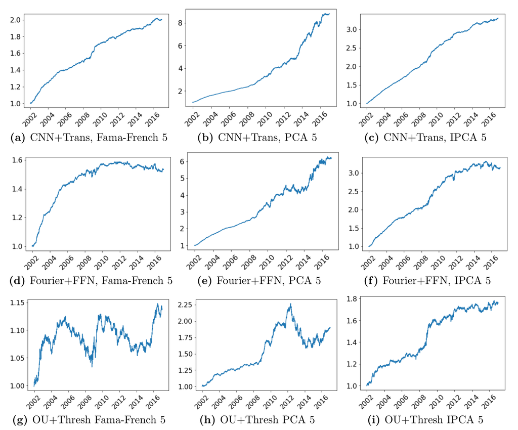

행 = 정책, 열 = 잔차 모형 (FF5 · PCA5 · IPCA5). OOS 2002–2016 (15년).

### 한국 (본 연구)

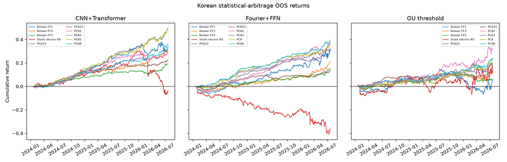

열 = 정책, 색 = 잔차 모형 (한국 FF1/3/5 · PCA $K$ = 0~15). OOS 2024-01 ~ 2026-07 (2.4년).

## 원 논문과 갈린 네 지점

|  | 현상 | 해석 |
| --- | --- | --- |
| **1** | 원 수익률($K$=0)이 음수 (미국 1.64) | 요인 지배력이 더 강해 pooling 전제가 더 크게 위배됨 |
| **2** | 단순 반전이 전 lag 음수 (미국 양수, 최대 0.3) | 한국에 단기 반전 프리미엄이 부재 |
| **3** | 비중 상위만 남기는 sparsification 이득 없음 | 수익원이 소수 종목이 아니라 횡단면 전반에 분산 |
| **4** | $K$ = 15에서 성과 하락 (미국은 평탄) | 일별 127~185종목에서 15팩터는 잔차의 정보를 고갈시킴 |

2번은 오히려 논문의 주장을 강화합니다 — 학습된 패턴이 단순 반전으로 설명되지 않는다는 결론이 한국에서 더 강하게 성립합니다. 4번은 유니버스 규모에서 직접 오는 제약입니다. 미국의 “$K$를 늘려도 평탄하다”는 결론은 $N \approx 550$에 의존하므로 한국에 그대로 이전되지 않습니다. 확장 연구의 자연스러운 출발점입니다.

## 유보사항

- **4.15는 마찰 부재 상한, 1.37이 실질값**입니다.
- **표본외 2.4년.** 원 논문 15년 대비 짧습니다 (질문 1).
- **price return 기준**이므로 원 논문의 total-return 경제성과 직접 비교되지 않습니다 (질문 2).
- **IPCA 잔차 미확보**로 원 논문의 IPCA 사양을 PCA 잔차에 대응시켰습니다 (질문 3).
- **PCA $K > 0$의 시점 처리** — 저자 공개 코드가 잔차 구성행렬 추정창에 당일 수익률을 포함하여 본문의 point-in-time 계약과 어긋납니다. 본 발표 수치는 공개 코드 기준이며 재실행이 필요합니다.
- 한국 성과가 전반적으로 높은 것은 **유니버스 규모(127~185 대 550)와 표본기간**에서 오는 착시일 수 있습니다.

# 3. 질문들

## 질문 1 — 표본외 기간

|  | 원 논문 (미국) | 현재 (한국) | 확보 가능 최대 |
| --- | --- | --- | --- |
| 원자료 | 1978 – 2016 | 2015-01 – 2026-07 | 2015-01 – 2026-07 |
| 잔차 표본 | 1998 – 2016 (19년) | 2020-01 – 2026-07 (1,606일) | 2016 – 2026 (약 10년) |
| **정책 OOS** | **2002 – 2016 (15년)** | **2024-01 – 2026-07 (2.4년)** | **약 6 – 7년** |

여쭙고 싶은 것

- 표본외 기간이 **어느 정도는 되어야** 하겠습니까?
- 2016년까지 앞당기면 6~7년이 됩니다. 전 구간 재실행이 필요한데 진행할까요?
- 기간을 늘리는 것과 현재 구간에서 분석을 더 하는 것 중 어느 쪽이 낫겠습니까?
- **enhanced index 펀드의 active 부분에 적용하는 확장**을 기여로 삼아도 되겠습니까?

## 질문 2 — 수익률 정의와 거래비용

|  | 원 논문 | 본 연구 현재 | 제안 |
| --- | --- | --- | --- |
| 수익률 | CRSP total return (배당 포함) | 권리·분할 조정 price return | **adjusted return 유지** |
| 거래비용 | 양방향 5 bp | 동일 | **매도금액 기준 20 bp + 3 bp** |
| 공매도 비용 | 보유 1 bp/일 | 동일 | **별도 모형화하지 않음** |
| 상장폐지 수익률 | 포함 | 미확보 | — |

한국은 공매도가 자유롭지 않고 대차 비용 추정도 어렵습니다. 배당은 기산일과 지급일의 시차 때문에 일별 백테스트에서 시점을 맞추기 어렵습니다.

여쭙고 싶은 것

- total return 대신 **adjusted return**으로 진행해도 됩니까?
- 공매도 비용을 따로 모형화하지 않고 **매도금액 기준 20 bp + 3 bp**로 처리해도 되겠습니까?
- 애초에 **공매도를 꼭 해야 합니까?** 벤치마크 대비 underweight로 구현하면 실제 공매도 없이 같은 active 포지션이 됩니다.

## 질문 3 — 팩터와 기업특성을 어떻게 만들 것인가

| 쟁점 | 현재 | 선택지 |
| --- | --- | --- |
| 팩터 구축 | 한국 FF 1/3/5를 재무 raw data에서 직접 구축 | 직접 구축 유지 / **JKP 팩터 사용** |
| 특성 집합 | 미국 46개 정의 이식 (427,076 종목-월) | 46개 유지 / 관측률 90% 이상으로 축소 |
| 표본 길이 | 논문 240개월, 국내 139개월 | 창 완화 후 sensitivity 표기 / 240개월 확보까지 보류 |
| 시점 정렬 | 공시일 vintage 부재 → 회계연도 말 + 3개월 고정 lag | 고정 lag 유지 / 공시일 자료 확보 |
| 수치 안정성 | $K$=5·60개월 ALS 비수렴 | $\Gamma$ 정칙화 (원 논문에 없음) / 특성 축소 |

여쭙고 싶은 것

- 팩터와 기업특성을 재무 데이터에서 **직접 구축**하는 게 맞습니까, **JKP** (Jensen, Kelly, and Pedersen 2023) 데이터를 써도 됩니까?
- JKP는 breakpoint·리밸런싱·가중이 Fama-French와 달라 **직접 구현이 맞아 보이는데** 동의하십니까? JKP는 검산용으로만 쓰면 어떻겠습니까?
- IPCA $\Gamma$ 정칙화는 원 논문에 없습니다. 한계로 명시하고 도입해도 됩니까?
- 팩터모형 선택이 부차적이라는 논문의 결론에 근거해, PCA·FF로 마무리하고 IPCA는 향후 과제로 남겨도 되겠습니까?